# US Diabetes Prediction

Amirhossein Mamhoudi

2023-09-05

## کتابخانه ها

اضافه کردن کتابخانه ها و تنظیم زبان فارسی

```r
Sys.setlocale(locale = 'persian')
```

```
## [1] "LC_COLLATE=Persian_Iran.1256;LC_CTYPE=Persian_Iran.1256;LC_MONETARY=Persian_Iran.1256;LC_NUMERIC=C;LC_TIME=Persian_Iran.1256"
```

```r
library(data.table)
library(ggplot2)
library(patchwork)
library(imager)
library(lemon)
library(caTools)
library(ROCR)
library(randomForest)
library(caret)
library(gmodels)
library(corrplot)
```

## خواندن داده ها

```r
d = fread('diabetes_binary_5050split_health_indicators_BRFSS2015.csv')
d$Diabetes_binary = as.factor(d$Diabetes_binary)
head(d)
```

```
##    Diabetes_binary HighBP HighChol CholCheck BMI Smoker Stroke
## 1:               0      1        0         1  26      0      0
## 2:               0      1        1         1  26      1      1
## 3:               0      0        0         1  26      0      0
## 4:               0      1        1         1  28      1      0
## 5:               0      0        0         1  29      1      0
## 6:               0      0        0         1  18      0      0
##    HeartDiseaseorAttack PhysActivity Fruits Veggies HvyAlcoholConsump
## 1:                    0            1      0       1                 0
## 2:                    0            0      1       0                 0
## 3:                    0            1      1       1                 0
## 4:                    0            1      1       1                 0
## 5:                    0            1      1       1                 0
## 6:                    0            1      1       1                 0
##    AnyHealthcare NoDocbcCost GenHlth MentHlth PhysHlth DiffWalk Sex Age
## 1:             1           0       3        5       30        0   1   4
## 2:             1           0       3        0        0        0   1  12
## 3:             1           0       1        0       10        0   1  13
## 4:             1           0       3        0        3        0   1  11
## 5:             1           0       2        0        0        0   0   8
## 6:             0           0       2        7        0        0   0   1
##    Education Income
## 1:         6      8
## 2:         6      8
## 3:         6      8
## 4:         6      8
## 5:         5      8
## 6:         4      7
```

## 1.آیا نتایج نظرسنجی BRFSS شانسی برای اینکه پیش‌بینی قابل قبولی از اینکه یک فرد دیابت دارد یا نه، ارائه ‌کند دارد؟ (یک بررسی توصیفی کفایت می‌کند، نیازی به مدلسازی نیست)

بله.برای مثال ارتباط چند متفیر را بین افراد بیمار و سالم بررسی می کنیم.مثلا افراد با سن بالا بیشتر بیمار بودند. افراد با شاخص سلامتی فیزیکی بالا و افرادی که دارای تحرک فیزیکی بودند به وضوح کم تر بیمار شدند. همه این ها نشان می دهد که می توان رابطه ای بین این مغیر ها و بیار بودن یک شخص یپدا کرد.

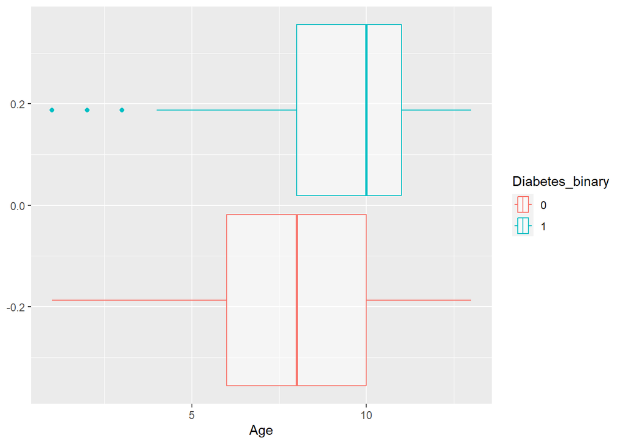

```r
ggplot(d, aes(Age, group = Diabetes_binary, color = Diabetes_binary))+
  geom_boxplot(alpha = .5)
```

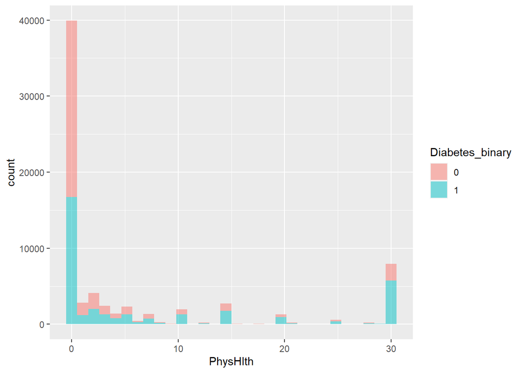

```r
ggplot(d, aes(PhysHlth, group = Diabetes_binary, fill = Diabetes_binary))+
  geom_histogram(alpha = .5)
```

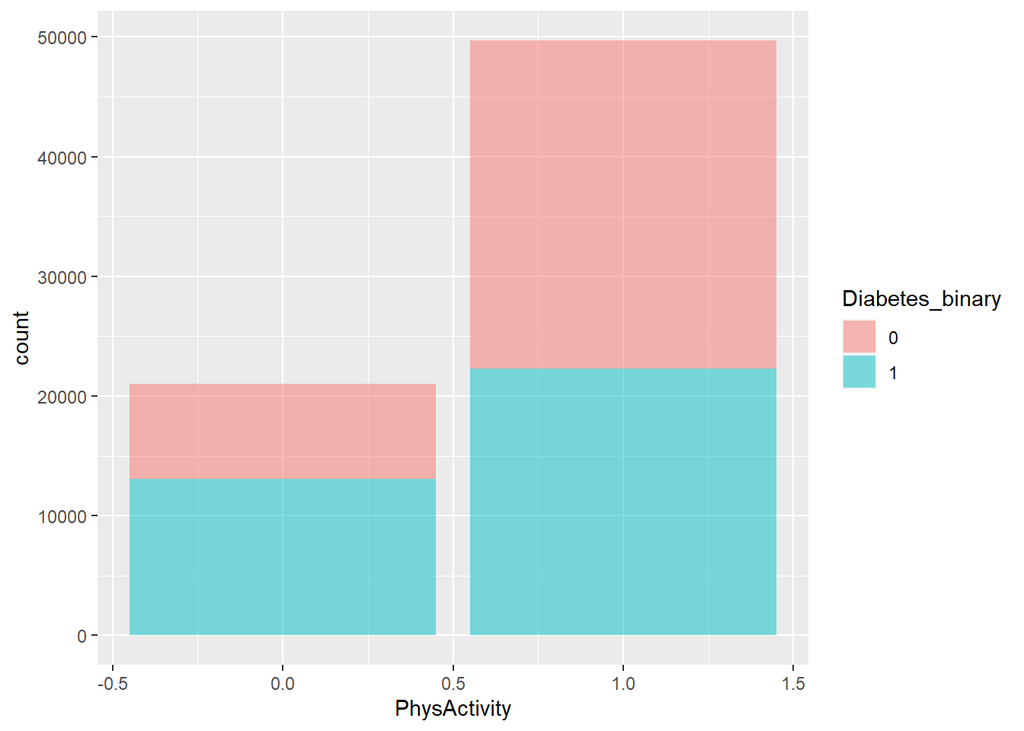

```r
ggplot(d, aes(PhysActivity, group = Diabetes_binary, fill = Diabetes_binary))+
  geom_bar(alpha = .5)
```

## 2.کدام عوامل خطر بیشترین قدرت پیش‌بینی ابتلا به دیابت را دارند؟

برای این کار از مدل random forest استفاده می کنیم: ابتدا داده را به سه بخش val, train ,test تقسیم می کنیم:

```r
# Splitting data in trainval and test data with ration 0.7
split <- sample.split(d$Diabetes_binary, SplitRatio = 0.7)
train_val <- subset(d, split == "TRUE")
test <- subset(d, split == "FALSE")
#split trainval to train and val with ration 0.85
val_split <- sample.split(train_val$Diabetes_binary, SplitRatio = 0.85)

val <- subset(train_val, val_split == "FALSE")
train <- subset(train_val, val_split == "TRUE")
```

حال مدل خود را می سازیم و آموزش می دهیم.

```r
# Fitting Random Forest to the train dataset
set.seed(120)  # Setting seed

rf = randomForest(x = train[,-1], y = train$Diabetes_binary, ntree = 500)

rf
```

```
##
## Call:
##  randomForest(x = train[, -1], y = train$Diabetes_binary, ntree = 500)
##                Type of random forest: classification
##                      Number of trees: 500
## No. of variables tried at each split: 4
##
##         OOB estimate of  error rate: 25.13%
## Confusion matrix:
##       0     1 class.error
## 0 15008  6023   0.2863868
## 1  4549 16482   0.2162997
```

```r
# Predicting the Test set results
y_pred <- predict(rf, newdata = val[,-1])
y_val<-as.factor(val$Diabetes_binary)
```

```r
#y_pred<-data.table("Diabetes_binary"=y_pred)
# Confusion Matrix
confusion_mtx <- confusionMatrix(data=y_pred, reference =y_val)
confusion_mtx
```

```
## Confusion Matrix and Statistics
##
##           Reference
## Prediction    0    1
##          0 2610  836
##          1 1101 2875
##
##                Accuracy : 0.739
##                  95% CI : (0.7289, 0.749)
##     No Information Rate : 0.5
##     P-Value [Acc > NIR] : < 2.2e-16
##
##                   Kappa : 0.478
##
##  Mcnemar's Test P-Value : 1.992e-09
##
##             Sensitivity : 0.7033
##             Specificity : 0.7747
##          Pos Pred Value : 0.7574
##          Neg Pred Value : 0.7231
##              Prevalence : 0.5000
##          Detection Rate : 0.3517
##    Detection Prevalence : 0.4643
##       Balanced Accuracy : 0.7390
##
##        'Positive' Class : 0
##
```

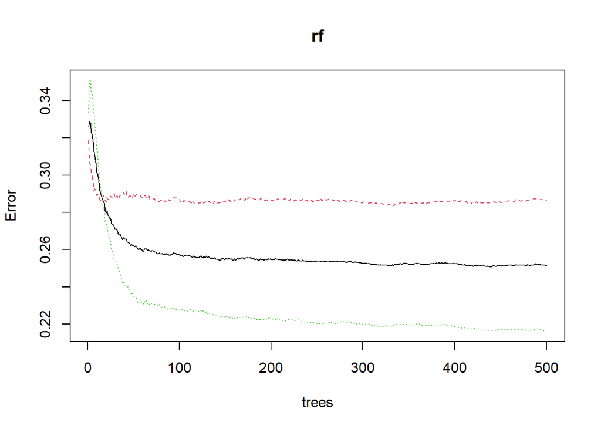

```r
# Plotting model
plot(rf)
```

```r
# Importance plot
rf_importance=importance(rf,Categorical=TRUE)
rf_importance
```

```
##                      MeanDecreaseGini
## HighBP                      1600.2944
## HighChol                     782.1512
## CholCheck                    126.0360
## BMI                         2626.1778
## Smoker                       423.7944
## Stroke                       180.1545
## HeartDiseaseorAttack         396.9671
## PhysActivity                 380.5294
## Fruits                       426.8236
## Veggies                      352.8273
## HvyAlcoholConsump            192.9011
## AnyHealthcare                139.6090
## NoDocbcCost                  215.4993
## GenHlth                     2114.5697
## MentHlth                     852.9508
## PhysHlth                    1127.0152
## DiffWalk                     535.2427
## Sex                          415.5424
## Age                         1997.4237
## Education                    866.3736
## Income                      1272.4262
```

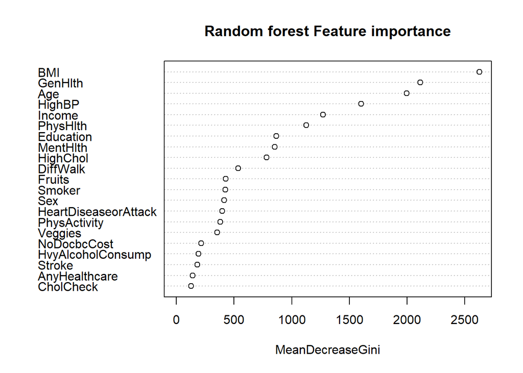

```r
# Variable importance plot
varImpPlot(rf,sort=TRUE,main='Random forest Feature importance')
```

به ترتیب مهم ترین متغیر ها مشخص هستند.برای مثال شاخص BMI و سلامت کلی و سن از مهم ترین متغیر ها هستند.

## 3.آیا می‌توانیم از زیرمجموعه‌ای از عوامل خطر برای پیش‌بینی اینکه یک فرد دیابت دارد یا نه، استفاده کنیم؟ به عبارت دیگر آیا می توانیم تنها از تعدادی از متغیرها در مدل استفاده کنیم و از بقیه صرف نظر کنیم؟ با چه روشی مدل نهایی را انتخاب می‌کنید؟

بله ممکن است.ما برای مثال 6 متغیر مهم را انتخاب می کنیم و با چند مدل مختلف بررسی میکنیم

```r
# Logistics Regression
glm_model <- glm(Diabetes_binary ~ BMI+GenHlth+Age+HighBP+Income+PhysHlth, data = train,family = binomial )

summary(glm_model)
```

```
##
## Call:
## glm(formula = Diabetes_binary ~ BMI + GenHlth + Age + HighBP +
##     Income + PhysHlth, family = binomial, data = train)
##
## Deviance Residuals:
##     Min       1Q   Median       3Q      Max
## -3.6033  -0.8336  -0.0670   0.8607   2.7436
##
## Coefficients:
##              Estimate Std. Error z value Pr(>|z|)
## (Intercept) -5.966435   0.096297 -61.959  < 2e-16 ***
## BMI          0.079205   0.001998  39.641  < 2e-16 ***
## GenHlth      0.638794   0.014052  45.460  < 2e-16 ***
## Age          0.185656   0.004674  39.718  < 2e-16 ***
## HighBP       0.892528   0.024713  36.116  < 2e-16 ***
## Income      -0.052568   0.005794  -9.074  < 2e-16 ***
## PhysHlth    -0.005427   0.001396  -3.888 0.000101 ***
## ---
## Signif. codes:  0 '***' 0.001 '**' 0.01 '*' 0.05 '.' 0.1 ' ' 1
##
## (Dispersion parameter for binomial family taken to be 1)
##
##     Null deviance: 58310  on 42061  degrees of freedom
## Residual deviance: 44219  on 42055  degrees of freedom
## AIC: 44233
##
## Number of Fisher Scoring iterations: 4
```

```r
glm_probs <- predict(glm_model, type = "response")

# Changing probabilities
glm_pred <- ifelse(glm_probs >0.5, 1, 0)
table ( glm_pred , train$Diabetes_binary )
```

```
##
## glm_pred     0     1
##        0 15146  5044
##        1  5885 15987
```

```r
mean(glm_pred ==train$Diabetes_binary )
```

```
## [1] 0.7401693
```

```r
print(c("accuracy of train data: ",mean(glm_pred ==train$Diabetes_binary )))
```

```
## [1] "accuracy of train data: " "0.740169273928962"
```

```r
glm_probs <- predict(glm_model,newdata=val[,c("BMI","GenHlth","Age","HighBP","Income","PhysHlth")], type = "response")

# Changing probabilities
glm_pred <- ifelse(glm_probs >0.5, 1, 0)
table ( glm_pred , val$Diabetes_binary )
```

```
##
## glm_pred    0    1
##        0 2628  919
##        1 1083 2792
```

```r
mean(glm_pred ==val$Diabetes_binary )
```

```
## [1] 0.7302614
```

```r
print(c("accuracy of val data: ",mean(glm_pred ==val$Diabetes_binary )))
```

```
## [1] "accuracy of val data: " "0.730261385071409"
```

```r
missing_classerr <- mean(glm_pred != val$Diabetes_binary)
print(paste('Accuracy =', 1 - missing_classerr))
```

```
## [1] "Accuracy = 0.730261385071409"
```

```r
# ROC-AUC Curve
ROCPred <- prediction(glm_pred, val$Diabetes_binary)
ROCPer <- performance(ROCPred, measure = "tpr",
                             x.measure = "fpr")

auc <- performance(ROCPred, measure = "auc")
auc <- auc@y.values[[1]]
auc
```

```
## [1] 0.7302614
```

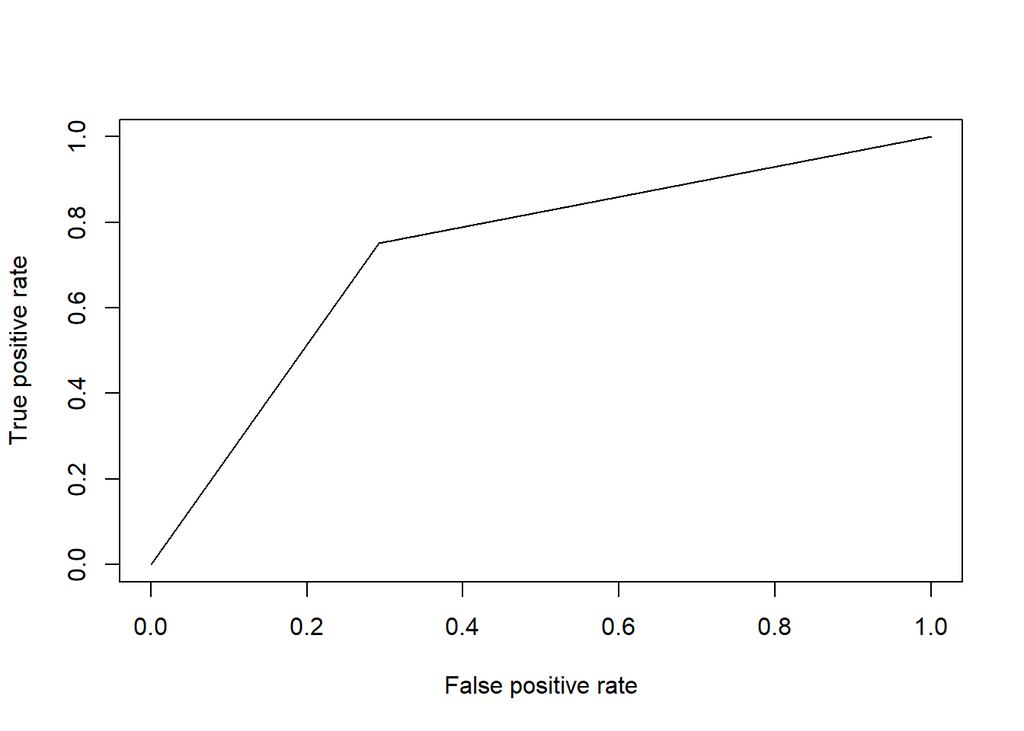

```r
# Plotting curve
plot(ROCPer)
```

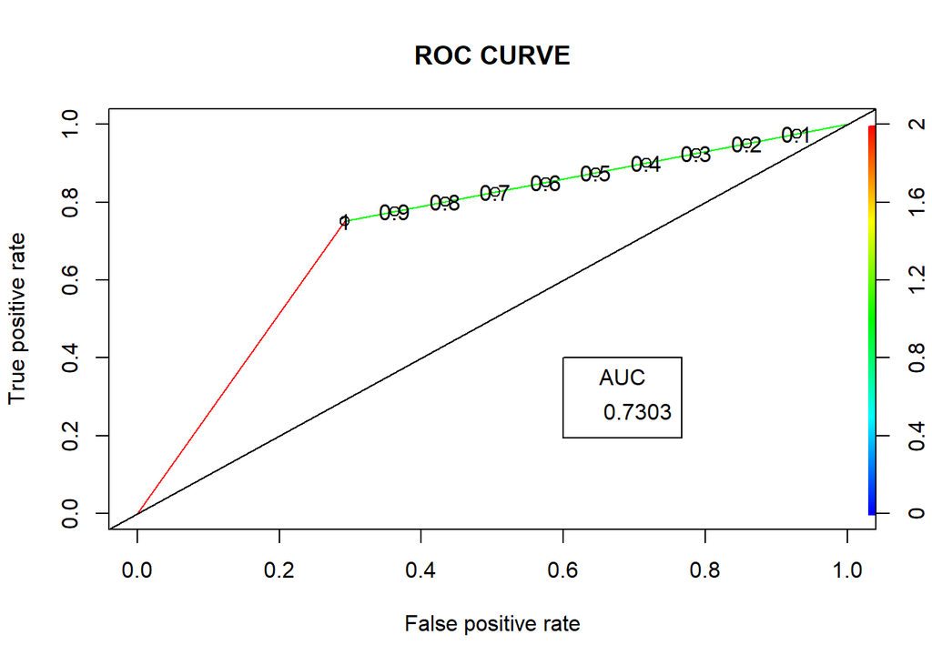

```r
plot(ROCPer, colorize = TRUE,
     print.cutoffs.at = seq(0.1, by = 0.1),
     main = "ROC CURVE")
abline(a = 0, b = 1)

auc <- round(auc, 4)
legend(.6, .4, auc, title = "AUC", cex = 1)
```

```r
rf_model = randomForest(Diabetes_binary ~ BMI+GenHlth+Age+HighBP+Income+PhysHlth, data = train, ntree = 500)

rf_model
```

```
##
## Call:
##  randomForest(formula = Diabetes_binary ~ BMI + GenHlth + Age +      HighBP + Income + PhysHlth, data = train, ntree = 500)
##                Type of random forest: classification
##                      Number of trees: 500
## No. of variables tried at each split: 2
##
##         OOB estimate of  error rate: 26.19%
## Confusion matrix:
##       0     1 class.error
## 0 14875  6156   0.2927108
## 1  4862 16169   0.2311825
```

```r
# Predicting the Test set results
rf_pred <- predict(rf_model, newdata = val[,c("BMI","GenHlth","Age","HighBP","Income","PhysHlth")])
```

```r
#y_pred<-data.table("Diabetes_binary"=y_pred)
# Confusion Matrix
confusion_mtx <- confusionMatrix(data=rf_pred, reference =y_val)
confusion_mtx
```

```
## Confusion Matrix and Statistics
##
##           Reference
## Prediction    0    1
##          0 2589  878
##          1 1122 2833
##
##                Accuracy : 0.7305
##                  95% CI : (0.7203, 0.7406)
##     No Information Rate : 0.5
##     P-Value [Acc > NIR] : < 2.2e-16
##
##                   Kappa : 0.4611
##
##  Mcnemar's Test P-Value : 5.521e-08
##
##             Sensitivity : 0.6977
##             Specificity : 0.7634
##          Pos Pred Value : 0.7468
##          Neg Pred Value : 0.7163
##              Prevalence : 0.5000
##          Detection Rate : 0.3488
##    Detection Prevalence : 0.4671
##       Balanced Accuracy : 0.7305
##
##        'Positive' Class : 0
##
```

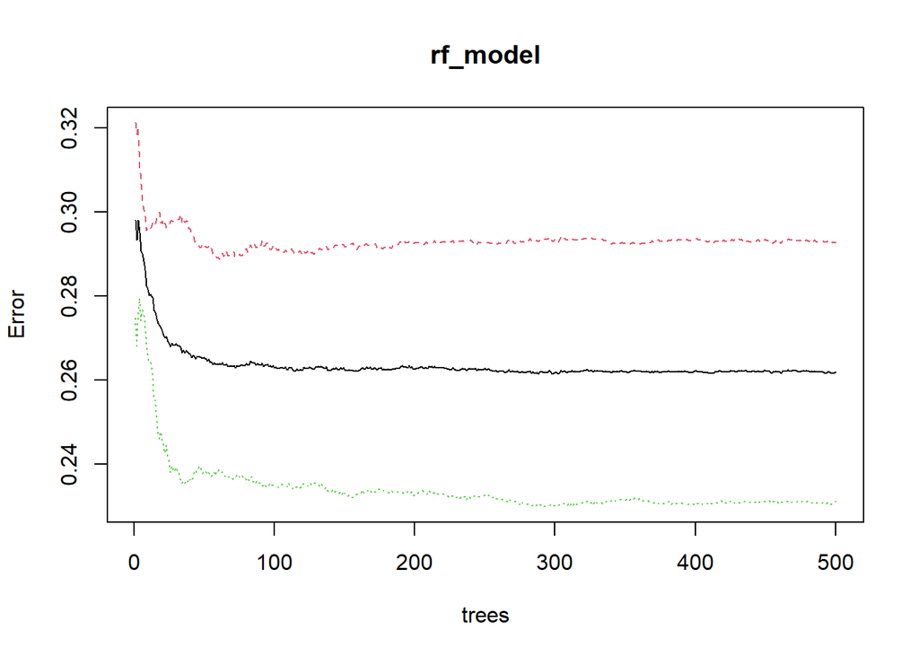

```r
# Plotting model
plot(rf_model)
```

می توانستیم مدل های بیشتری را هم بررسی کنیم اما تقریبا نتایح مشابه خواهند بود.در این جا هم تقریبا دقت ها مثل هم هستند.ما برای اینکه روش لاجستیک کمی بهتر قابل تحلیل است از آن به عنوان مدل نهایی استفاده می کنیم.

## 4.کدام متغیرها در مدل نهایی شما نقش بازی می‌کنند و عملکرد مدل پیش‌بینی با استفاده از آن‌ها چگونه است؟ استراتژی شما برای استفاده از داده‌ train و validation و test در ساخت مدل و گزارش عملکرد آن چیست؟

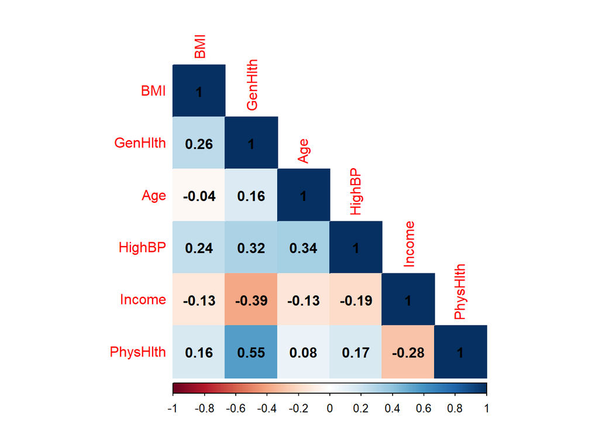

```r
# Calculate the correlation matrix
cor_mat <- cor(data.frame(train[,c("BMI","GenHlth","Age","HighBP","Income","PhysHlth"), with = FALSE]))

# Plot the correlation heatmap
corrplot(cor_mat, method = "color", type = "lower", addCoef.col = "black")
```

```r
summary(glm_model)
```

```
##
## Call:
## glm(formula = Diabetes_binary ~ BMI + GenHlth + Age + HighBP +
##     Income + PhysHlth, family = binomial, data = train)
##
## Deviance Residuals:
##     Min       1Q   Median       3Q      Max
## -3.6033  -0.8336  -0.0670   0.8607   2.7436
##
## Coefficients:
##              Estimate Std. Error z value Pr(>|z|)
## (Intercept) -5.966435   0.096297 -61.959  < 2e-16 ***
## BMI          0.079205   0.001998  39.641  < 2e-16 ***
## GenHlth      0.638794   0.014052  45.460  < 2e-16 ***
## Age          0.185656   0.004674  39.718  < 2e-16 ***
## HighBP       0.892528   0.024713  36.116  < 2e-16 ***
## Income      -0.052568   0.005794  -9.074  < 2e-16 ***
## PhysHlth    -0.005427   0.001396  -3.888 0.000101 ***
## ---
## Signif. codes:  0 '***' 0.001 '**' 0.01 '*' 0.05 '.' 0.1 ' ' 1
##
## (Dispersion parameter for binomial family taken to be 1)
##
##     Null deviance: 58310  on 42061  degrees of freedom
## Residual deviance: 44219  on 42055  degrees of freedom
## AIC: 44233
##
## Number of Fisher Scoring iterations: 4
```

برای تقسیم داده های برای آموزش و تست اما داده ها را به سه بخش تقسیم میکنیم .بخش تست را کلا کنار می گذاریم تا در آخر آخر کار که خیلی نیاز است از آن استفاده کنیم.قبل از آن نباید از تست استفاده کرد تا داده ای برای یک روز مبادا یا حتی هیوقت! داشته باشیم.بخش دیگر راب به ترین و ولدیشین تقسیم میکنیم و کارمان را با آن انجام می دهیم.